# Week 2 Practical Exercises

This week will have a relatively small number of new exercises so that you can complete the exercises from week 1. Please complete the exercises from week 1 before attempting the exercises of this week.

# 1. Classify digits using the MNIST dataset

For the exercises of this section, we will use the MNIST dataset. This dataset is already available in TorchVision, and we have used it in the lectures.

## 2.1 Count labels

Edit the function `summary_mnist` in file `week2.py` so that it returns the counts of labels in the training set and the test set. The function receives the following:

- `train_labels`: the list of labels from the training set.
- `test_labels`: the list of labels from the test dataset.
- `labels_list`: the list of unique labels from the dataset.

The output must be a Python dictionary with the following two items:

- `"train_labels_counts"`: The counts of occurrences in `train_labels` for each label listed in `labels_list`.
- `"test_labels_counts"`: The counts of occurrences in `test_labels` for each label listed in `labels_list`.

An example of use of this function is:

```python
from torchvision import datasets
import torch
import numpy as np

device = "cuda" if torch.cuda.is_available() else "cpu"
print("The device is", device)
```

```
The device is cpu
```

```python
data_folder = "MNIST"
train_mnist = datasets.MNIST(data_folder, download=True, train=True)
test_mnist = datasets.MNIST(data_folder, download=True, train=False)

train_images = train_mnist.data
train_targets = train_mnist.targets
test_images = test_mnist.data
test_targets = test_mnist.targets
```

```python
import week2
labels_counts = week2.summary_mnist(train_targets.tolist(), test_targets.tolist(), range(10))
labels_counts
```

```
{'train_labels_counts': [5923,
  6742,
  5958,
  6131,
  5842,
  5421,
  5918,
  6265,
  5851,
  5949],
 'test_labels_counts': [980, 1135, 1032, 1010, 982, 892, 958, 1028, 974, 1009]}
```

This means that label 0 has a count of 5923 in the training data and 980 in the test data, and so on with labels 1, 2, ... 9. With this information you can, for example, do these plots:

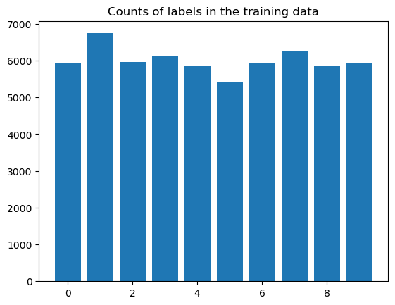

```python
%matplotlib inline
from matplotlib import pyplot as plt
plt.bar(range(10), labels_counts['train_labels_counts'])
plt.title("Counts of labels in the training data")
plt.show()
```

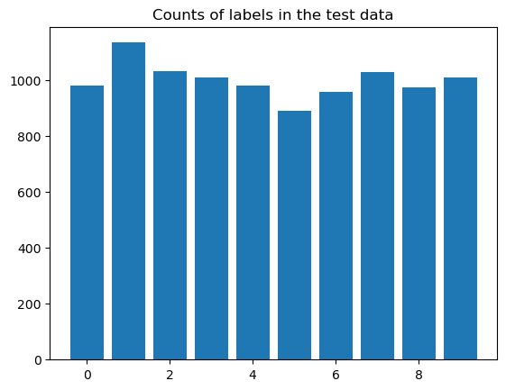

```python
plt.bar(range(10), labels_counts['test_labels_counts'])
plt.title("Counts of labels in the test data")
plt.show()
```

Answer the following questions:

1. Are the data balanced? (in other words, do all labels have a similar number of counts?)
2. Do the train and test data have similar distributions of labels?

## 2.2 Classify digits

Edit the function `build_mnist_model` so that it returns a pytorch model to classify the MNIST data. The resulting model must contain a hidden layer with a ReLU activation, followed by the final classification layer. Make sure that the last layer has the correct size.

The function has the following parameter:

- `hidden_size`: size of the hidden layer.

An example of use of this function is:

```python
import week2
mnist_model = week2.build_mnist_model(64)
```

```python
!pip install torch_summary
from torchsummary import summary
summary(mnist_model);
```

```
=================================================================
Layer (type:depth-idx)                   Param #
=================================================================
├─Flatten: 1-1                           --
├─Linear: 1-2                            50,240
├─ReLU: 1-3                              --
├─Linear: 1-4                            650
=================================================================
Total params: 50,890
Trainable params: 50,890
Non-trainable params: 0
=================================================================
```

Use the following code to train a classifier using different values for the hyperparameters (in this exercise, there is only one hyperparameters, the hidden layer size). Answer the following questions:

1. What are the optimal hyperparameters?
2. Does the model overfit? How can you determine whether it is overfitting?

### 2.2.1 Definitions

```python
from torch import nn, optim
from torchvision import transforms
from torch.utils.data import DataLoader

data_folder = "MNIST"
```

```python
transform = transforms.Compose([
    transforms.ToTensor(),
    # transforms.Normalize((0.1307,), (0.3081,)) # Mean and Std dev for MNIST
])

train_dataset = datasets.MNIST(data_folder, train=True, download=True, transform=transform)
test_dataset = datasets.MNIST(data_folder, train=False, transform=transform)
```

```python
batch_size = 64
train_loader = DataLoader(train_dataset, batch_size=batch_size, shuffle=True)
test_loader = DataLoader(test_dataset, batch_size=batch_size, shuffle=False)
```

```python
# since there's no need for updating weights,
# we might as well not compute the gradients.
# Using this '@' decorator on top of functions
# will disable gradient computation in the entire function
@torch.no_grad()
def count_correct(x, y, model):
    model.eval() # Set the model to the "evaluation" mode

    # get the prediction matrix for a tensor of `x` images
    prediction = model(x)

    # compute if the location of maximum in each row
    # coincides with ground truth. The function `max`
    # returns both maximum values and their locations. It takes as argument
    # the dimension along which the maximum is computed. If the value is -1,
    # it computes the maximum along the last dimension.
    max_values, argmaxes = prediction.max(-1)

    # compute the accuracy by checking if the locations of maximum values
    # coincide with the ground truth values `y`
    is_correct = argmaxes == y
    return is_correct.sum().item()
```

```python
epochs = 5
loss_function = nn.CrossEntropyLoss()
def train(model, optimizer):
    accuracies = []
    losses = []
    model.train()
    for epoch in range(epochs):
        epoch_accuracies = []
        epoch_losses = []

        for batch_idx, (data, target) in enumerate(train_loader):
            data, target = data.to(device), target.to(device)

            # Forward pass
            outputs = model(data)
            loss = loss_function(outputs, target)
            batch_loss = loss.item()
            batch_accuracy = count_correct(data, target, model)/len(data)
            epoch_losses.append(batch_loss)
            epoch_accuracies.append(batch_accuracy)

            # Backward pass and optimization
            optimizer.zero_grad()
            loss.backward()
            optimizer.step()

        epoch_loss = sum(epoch_losses) / len(epoch_losses)
        epoch_accuracy = sum(epoch_accuracies) / len(epoch_accuracies)
        losses.append(epoch_loss)
        accuracies.append(epoch_accuracy)

        print(f"Epoch [{epoch+1}/{epochs}], Loss: {loss.item():.4f}, Accuracy: {epoch_accuracy:.4f}")
    return losses, accuracies
```

### 2.2.2 Training

```python
# Modify this line with your choice of hyperparameters
model = week2.build_mnist_model(64).to(device)
```

```python
learning_rate = 0.001
optimizer = optim.Adam(model.parameters(), lr=learning_rate)
```

```python
losses, accuracies = train(model, optimizer)
```

```
Epoch [1/5], Loss: 0.1094, Accuracy: 0.8944
Epoch [2/5], Loss: 0.3639, Accuracy: 0.9427
Epoch [3/5], Loss: 0.1397, Accuracy: 0.9570
Epoch [4/5], Loss: 0.1256, Accuracy: 0.9656
Epoch [5/5], Loss: 0.0223, Accuracy: 0.9713
```

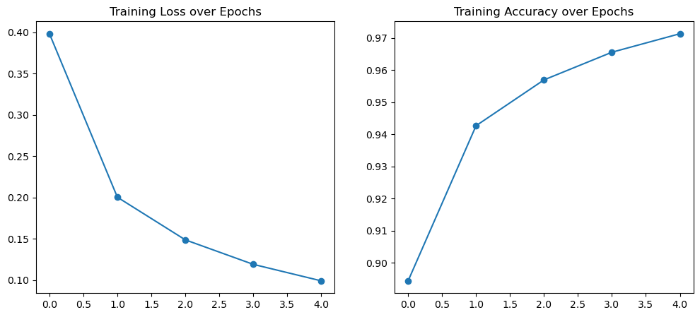

```python
plt.figure(figsize=(12, 5))
plt.subplot(1, 2, 1)
plt.plot(losses, marker='o')
plt.title('Training Loss over Epochs')
plt.subplot(1, 2, 2)
plt.plot(accuracies, marker='o')
plt.title('Training Accuracy over Epochs')
plt.show()
```

### 2.2.3 Test

```python
def test(loader):
    test_loader = loader
    model.eval()
    test_loss = 0
    test_accuracy = 0
    with torch.no_grad():
        for data, target in test_loader:
            data, target = data.to(device), target.to(device)
            output = model(data)
            test_loss += loss_function(output, target).item()  # Sum up batch loss
            test_accuracy += count_correct(data, target, model)  # Sum up correct predictions
    test_loss /= len(test_loader.dataset)  # Average loss
    test_accuracy /= len(test_loader.dataset)  # Average accuracy
    print("Test loss:", test_loss)
    print("Test accuracy:", test_accuracy)
```

```python
test(train_loader)
```

```
Test loss: 0.0012811594665516168
Test accuracy: 0.9759166666666667
```

```python
test(test_loader)
```

```
Test loss: 0.001625422680110205
Test accuracy: 0.9676
```

# 3. Using the webcam

The following code illustrates how you can classify the first 5 images of the test data:

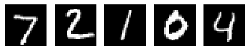

```python
%matplotlib inline
from matplotlib import pyplot as plt
for i in range(5):
    plt.subplot(1,5,1+i)
    plt.axis('off')
    plt.imshow(test_images[i], cmap="gray")
plt.show()
```

```python
# Classify the image
for i in range(5):
    img, label = test_dataset[i]
    input_batch = img.unsqueeze(0).to(device)  # Add batch dimension and move to device
    print("The target label is", test_targets[i].item())
    print("The predicted label is", model(img).argmax().item())
```

```
The target label is 7
The predicted label is 7
The target label is 2
The predicted label is 2
The target label is 1
The predicted label is 1
The target label is 0
The predicted label is 0
The target label is 4
The predicted label is 4
```

The following code uses the webcam to classify handwritten items. It follows these steps:

1. Capture an image from the webcam and save it into the variable `captured_image`. **If you have multiple webcams attached to your device, you may need to change the argument in the function call `cv2.VideoCapture`**. Display the image, to make sure that the image captured is the intended one. The image is preprocessed to fit the MNIST data by applying these transformations:
   - crop the image so that the number fits the entire image. Feel free to change the level of cropping to fit your webcam.
   - Convert to greyscale using `cv2.COLOR_BGR2GRAY`
   - Invert the luminosity so that the number is white on a black background
2. Apply the model stored in variable `model` to the image captured and prints the predicted label. Please make sure that `model` contains the best model generated in exercise 2.

Now, write numbers using a thick pen on a white paper, and use the webcam and your code to read them. How did the classification system perform? Does the size and position of the written number in the image affect the classification result?

## 3.1 Capture an image using the webcam

```python
%matplotlib inline
import matplotlib.pyplot as plt
import cv2
```

```python
# Initialize the webcam
print("Initialising video capture")
cap = cv2.VideoCapture(0) # Change the argument to 1 or 2 if you have multiple webcams
                          # and the default one is not the one you want to use

# Check if the webcam is opened correctly
if cap.isOpened():
    print("Webcam initialised. Capturing frames.")
else:
    print("Error: Could not open webcam.")
```

```
Initialising video capture
Webcam initialised. Capturing frames.
```

```
Capturing frame
```

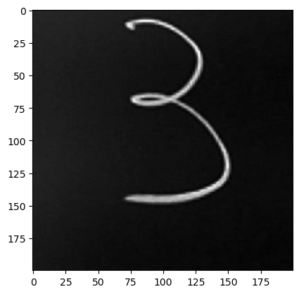

```python
# Run this cell multiple times, until we are satisfied with the image

# Capture a single frame
print("Capturing frame")
ret, frame = cap.read()

# Check if the frame was captured correctly
if not ret:
    print("Error: Could not read frame.")

captured = cv2.cvtColor(frame, cv2.COLOR_BGR2GRAY)

# Crop the image to zoom it in (if needed)
cropped = captured[100:300, 100:300]

# Invert the image luminosity to match the MNIST dataset
captured_image = 255 - cropped


plt.imshow(captured_image, cmap="gray")
plt.show()
```

## 3.2 Classify the image

```python
from torchvision import transforms

# Use transforms to resize the image to 28x28, and convert it to a tensor
preprocess = transforms.Compose([
    transforms.ToPILImage(),  # Convert the NumPy array to a PIL image
    transforms.Resize((28, 28)),
    transforms.ToTensor()
])

input_image = preprocess(captured_image).unsqueeze(0).to(device)  # Add batch dimension and move to device
```

```python
# Classify the image
print("The predicted label is", model(input_image).argmax().item())
```

```
The predicted label is 3
```

```python
# Print all prediction probabilities
predictions = model(input_image)
print(predictions.softmax(-1))
```

```
tensor([[6.3157e-06, 1.6997e-08, 1.0264e-01, 8.3597e-01, 2.3021e-17, 6.1163e-02,
         1.6222e-07, 2.1234e-04, 6.1286e-08, 4.2800e-09]],
       grad_fn=<SoftmaxBackward0>)
```

```python
# Release the webcam
print("Releasing webcam")
cap.release()
```

```
Releasing webcam
```

# 4. Post-practical questionnaire

Please complete the week 2 post-practical questionnaire on iLearn.